# Exercise 1

## Background on Fishery

**Arctic sardine (*Pseudosardina arctica*)**

The Arctic sardine is a fictional small pelagic species with a mean generation time of 5 years. It is a schooling fish that forms predictable aggregations for feeding, overwintering, and spawning. Suppose the Arctic sardine stock is divided in multiple management units (MUs) for the purposes of assessment and management (Figure 1):  
• MU1 (West spawning component)  
• MU2 (East offshore spawning component)  
• MU3 (East nearshore spawning component)  
Each MU has several spawning areas and there is mixing of Arctic Sardine among the MUs during annual feeding and overwintering migrations. It is assumed that Arctic Sardine exhibit spawning-area fidelity such that during the spawning season, the fish are separated by MU. Acoustic surveys conducted on the spawning grounds therefore represent a measure of spawning stock biomass for the specific MU.

**Table 1. Description of Management Units**

[output not shown]

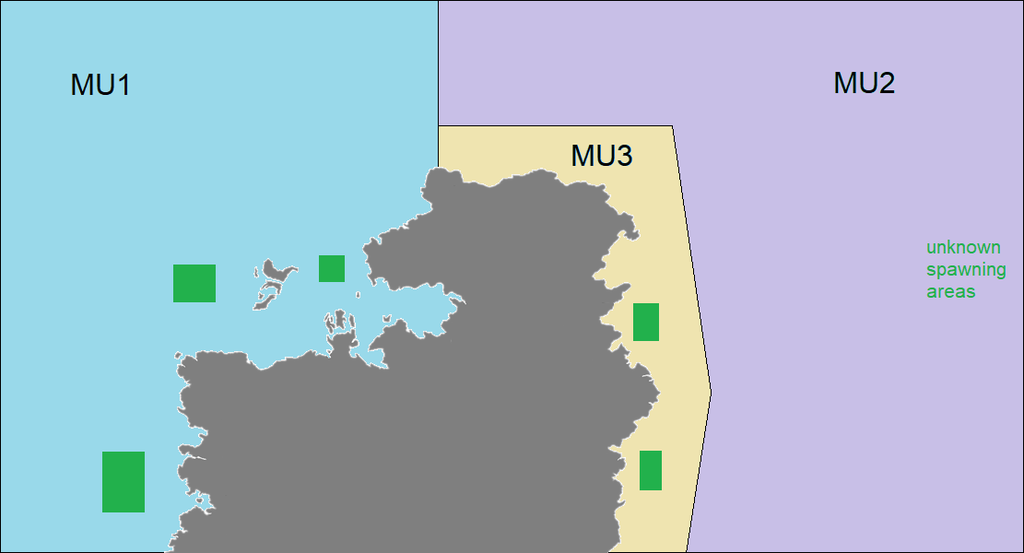

**Figure 1. Map of the Arctic Sardine Management Units (MU1, MU2, MU3).**  
*Green polygons = known spawning areas and locations of acoustic surveys during the fall spawning season*

## Figures

### Entire Stock (MU1,2,3)

Consider the suitability of these potential indicators for Arctic sardine (pelagic forage fish) for the entire stock area:  
• Total biomass index for the spring groundfish bottom trawl survey (some coverage in MU1 and MU2 only)  
• Acoustic spawning stock biomass index on known spawning grounds in the fall (full coverage in MU1 and MU3, no coverage in MU2)

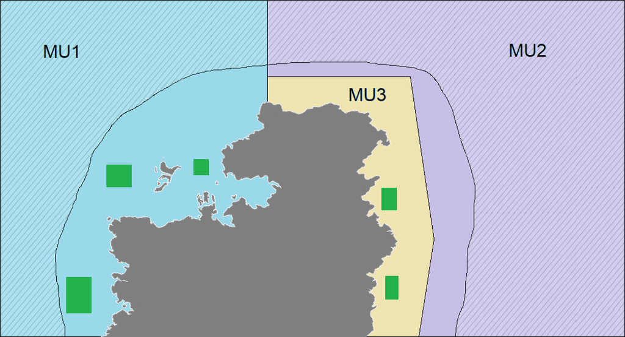

**Figure 2.1.1 Map of Entire Stock Area (MU1, MU2, and MU3)**  
Notes:  
*Hatched area = spring groundfish bottom trawl survey coverage*  
*green polygons = acoustic survey coverage on spawning grounds in the fall*

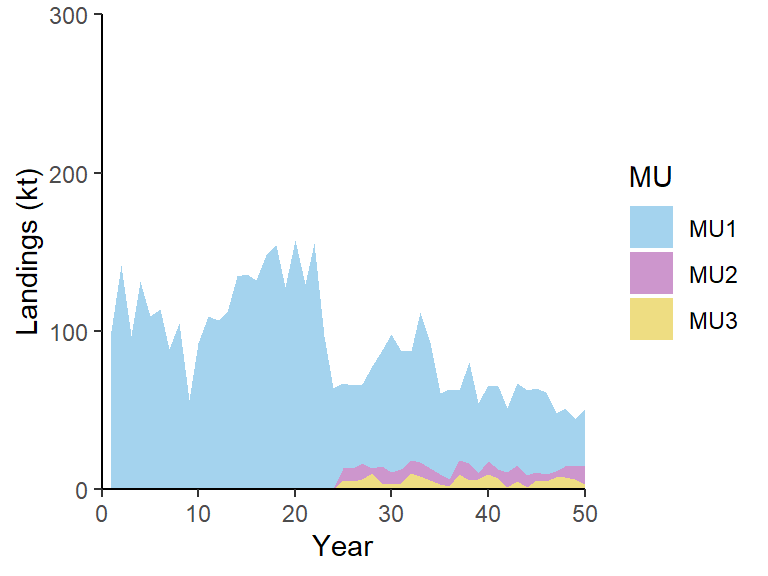

**Fig 2.1.2 Historical Landings by Management Unit (MU) (Years 1-50)**

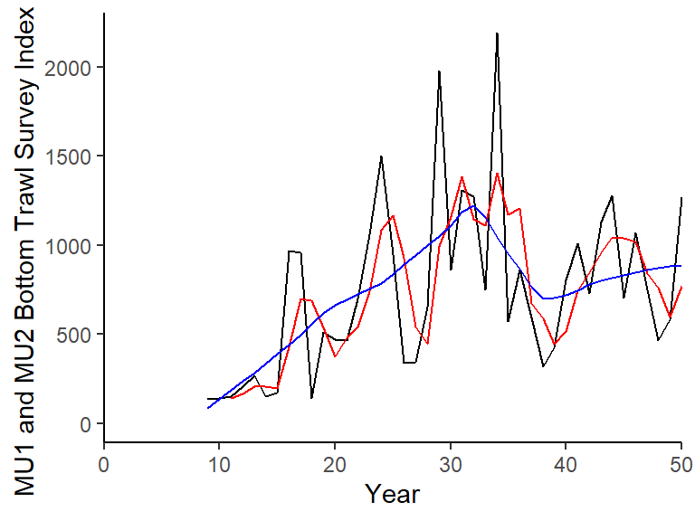

**Fig 2.1.3 Biomass Index from the Spring Groundfish Bottom Trawl Survey for MU1 and MU2**  
*Notes:* *Index is a relative index of total “benthic” biomass* *Red line = 3 year moving average* *Blue line = loess smoother with span = 0.5*

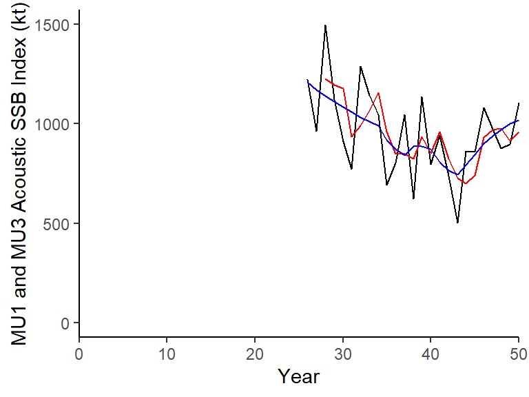

**Fig 2.1.4 Spawning Stock Biomass Index from Acoustic Surveys on the Spawning Grounds for MU1 and MU3 during the Fall Spawning Season**  
*Notes:* *Index is a relative index of SSB* *Black line = Annual index*  
*Red line = 3 year moving average* *Blue line = loess smoother with span = 0.5*

### MU1

Consider the suitability of these potential indicators for Arctic sardine (pelagic forage fish) in MU1:  
• Total catch, CPUE for purse seine fleet (~80% of catches in MU1)  
• Total biomass index for the groundfish bottom trawl survey (some coverage in MU1)  
• Acoustic spawning stock biomass index on known spawning grounds (full coverage in MU1)

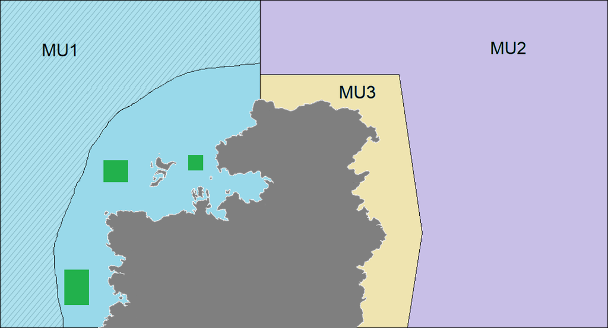

**Figure 2.2.1 Map of MU1**  
Notes:  
*Hatched area = spring groundfish bottom trawl survey coverage*  
*green polygons = acoustic survey coverage on spawning grounds in the fall*

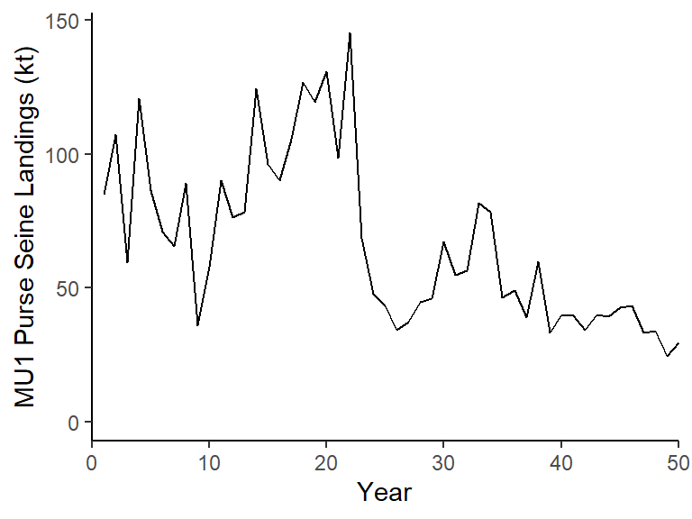

**Figure 2.2.2 Landings for Purse Seine Fleet in MU1**

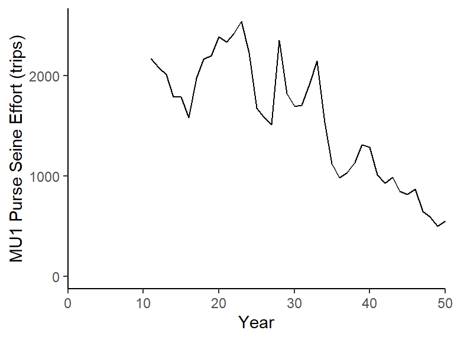

**Figure 2.2.3 Total Effort for Purse Seine Fleet in MU1**

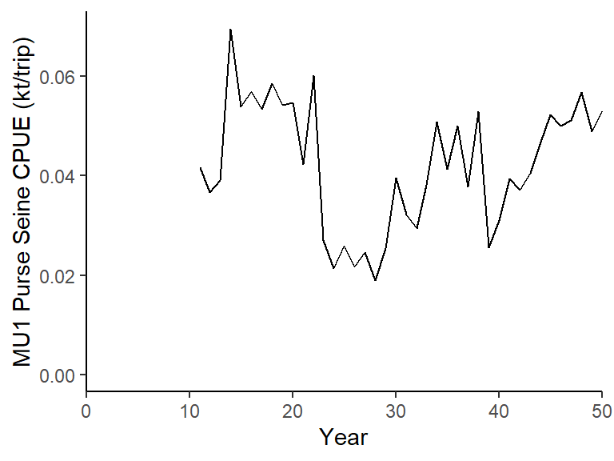

**Figure 2.2.4 CPUE for Purse Seine Fleet in MU1**

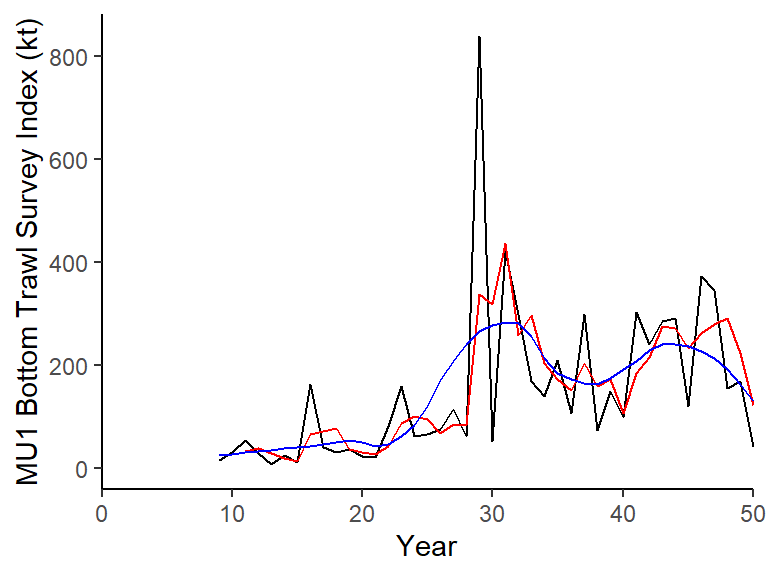

**Figure 2.2.5 Biomass Index from the Spring Groundfish Bottom Trawl Survey for MU1**  
*Notes:*  
*Index is a relative index of total “benthic” biomass*  
*Red line = 3 year moving average*  
*Blue line = loess smoother with span = 0.5*

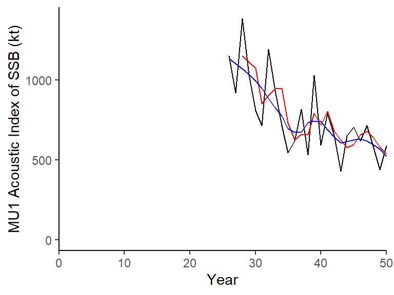

**Figure 2.2.6 Spawning Stock Biomass Index from Acoustic Surveys on the 3 Spawning Grounds for MU1 during the Fall Spawning Season**  
*Notes:*  
*Index is a relative index of SSB*  
*Red line = 3 year moving average*  
*Blue line = loess smoother with span = 0.5*